# Some serious data massaging

## Grouping data to `mutate` or `summarise`

Now we would like to label each plot by its final composition, so that we can contrast communities subject to the drought treatment with those in the control group. In particular, we are going to add a community label to each row, obtained by stringing together all the `shortname`s of the species in each mesocosm/treatment combination.

To accomplish this, we need to group the data by `label` (i.e., by mescosm) and by `treatment` (i.e, drought/control); when we invoke `group_by`, we are adding an invisible column specifying the group structure; we can then perform operations on each group separately.

Two of the most useful operations on grouped data:

- `mutate` creates a new column based on the contents of other columns; you can apply mutate by group
- `summarise` creates summaries for the data, producing a new table. Typically, the functions you apply take a vector as input (e.g., all the biomasses in a treatment) and return a single value (e.g., the average biomass for the treatment)

The ability to work on grouped data is one of the most useful features of `tidyverse`. We are going examine an example of `mutate` and one of `summarise`.

```r
dt2 <- dt2 %>%
  # this adds an invisible column specifying group structure
  group_by(label, treatment) %>%
  # mutate is used to create a new column that is a function of the
  # current columns
  mutate(community_label = paste(sort(shortname), collapse = "-"))
dt2
```

```
# A tibble: 193 × 6
# Groups:   label, treatment [67]
   label    treatment species               shortname biomass community_label
   <chr>    <chr>     <chr>                 <chr>       <dbl> <chr>
 1 C-1      C         Anthoxanthum odoratum Ao          18.8  Ao
 2 C-123    C         Anthoxanthum odoratum Ao           8.63 Ao-Fr
 3 C-123    C         Festuca rubra         Fr           3.08 Ao-Fr
 4 C-123567 C         Anthoxanthum odoratum Ao           3.3  Ao-Fr-Ra-Rua-Sg
 5 C-123567 C         Festuca rubra         Fr           1.01 Ao-Fr-Ra-Rua-Sg
 6 C-123567 C         Ranunculus acris      Ra           1.73 Ao-Fr-Ra-Rua-Sg
 7 C-123567 C         Rumex acetosa         Rua          1.67 Ao-Fr-Ra-Rua-Sg
 8 C-123567 C         Stellaria graminea    Sg           1.46 Ao-Fr-Ra-Rua-Sg
 9 C-124678 C         Anthoxanthum odoratum Ao           3.59 Ao-Eh-Fr-Hl-Ra-Rua
10 C-124678 C         Epilobium hirsutum    Eh           1.08 Ao-Eh-Fr-Hl-Ra-Rua
# … with 183 more rows
```

```r
# if we want to remove the group information, use `ungroup`
dt2 <- dt2 %>% ungroup()
```

Now we can plot the biomass of each species in each community for the treatment/no treatment:

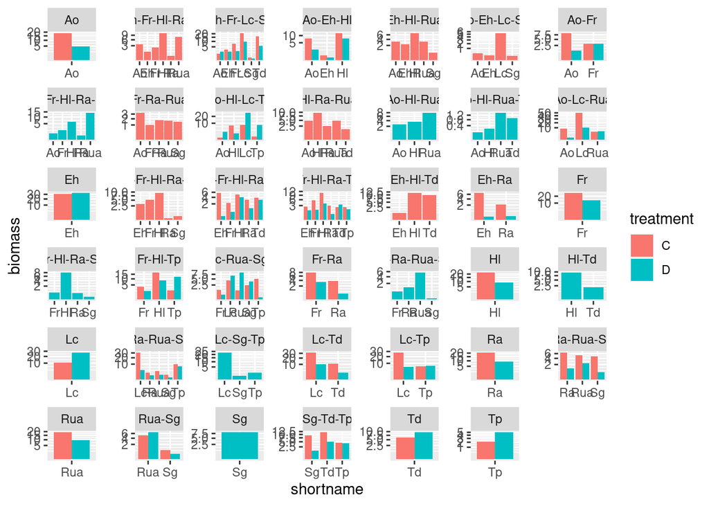

```r
dt2 %>%  # color by treatment
  ggplot(aes(x = shortname, y = biomass, fill = treatment)) +
  # plot bars next to each other
  geom_col(position = "dodge") +
  # one panel per community
  facet_wrap(~community_label, scales = "free")  +
  # use sqrt scale in y axis
  scale_y_sqrt()
```

Note that some communities are present only in the treatment or no treatment groups, because the other community has collapsed. We can filter to use only those that are present in both by counting the number of treatments by community:

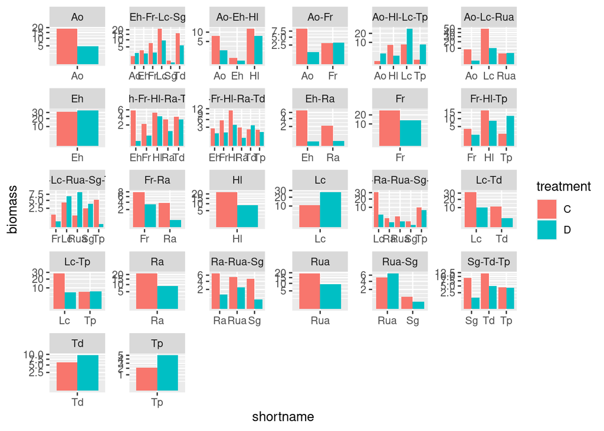

```r
unpaired <- dt2 %>%
  # select only distinct combos of community_label and treatment
  select(community_label, treatment) %>%
  distinct() %>%
  # count how many treatments for community_label
  count(community_label) %>%
  # we want to eliminate those with less than 2 treatments
  filter(n < 2) %>%
  # importantly, we want to keep only the community_labels
  select(community_label) # these are the labels of unpaired

dt2 %>%  # remove unpaired
  anti_join(unpaired) %>%
  ggplot(aes(x = shortname, y = biomass, fill = treatment)) +
  geom_col(position = "dodge") +
  facet_wrap(~community_label, scales = "free")  +
  scale_y_sqrt()
```

Note that in many cases the control treatment yields higher biomass. To have a more straightforward visualization, we can find the total biomass per mesocosm/treatment and plot the values for each community:

```r
total_biom <- dt2 %>%
  group_by(label, community_label, treatment) %>%
  # total biomass per mesocosm
  summarise(biomass = sum(biomass),
            nsp = n(), # total num species in community
            .groups = "drop") %>%
  # now make a table with total biom for C and D in separate cols
  select(community_label, treatment, biomass, nsp) %>%
  pivot_wider(names_from = treatment, values_from = biomass)
total_biom
```

```
# A tibble: 41 × 4
   community_label      nsp     C     D
   <chr>              <int> <dbl> <dbl>
 1 Ao                     1 18.8   4.83
 2 Ao-Fr                  2 11.7   4.13
 3 Ao-Fr-Ra-Rua-Sg        5  9.17 NA
 4 Ao-Eh-Fr-Hl-Ra-Rua     6 26.0  NA
 5 Ao-Eh-Fr-Lc-Sg-Td      6 49.4  21.8
 6 Ao-Eh-Hl-Rua-Sg        5 16.2  NA
 7 Ao-Hl-Lc-Tp            4 16.4  38.7
 8 Ao-Eh-Lc-Sg            4  6.14 NA
 9 Ao-Hl-Ra-Rua-Td        5 23.3  NA
10 Ao-Eh-Hl               3 20.5   9.75
# … with 31 more rows
```

And plot:

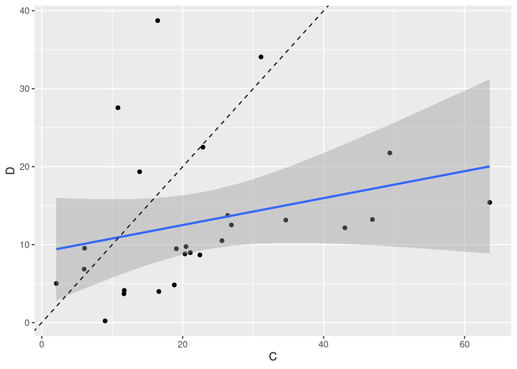

```r
total_biom %>%
  drop_na() %>%
  ggplot(aes(x = C, y = D)) +
  geom_point() +
  geom_smooth(method = "lm") +
  geom_abline(slope = 1, intercept = 0, linetype = 2)
```

We can also check whether the differences are due to the number of species:

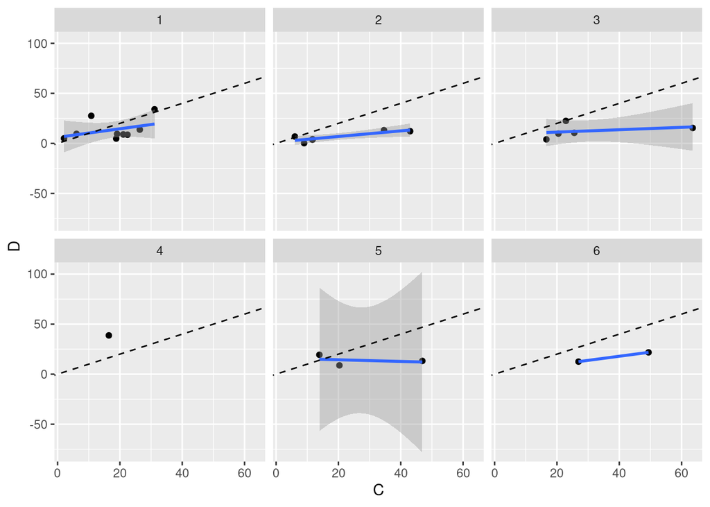

```r
total_biom %>%
  drop_na() %>%
  ggplot(aes(x = C, y = D)) +
  geom_point() +
  geom_smooth(method = "lm") +
  facet_wrap(~nsp) +
  geom_abline(slope = 1, intercept = 0, linetype = 2)
```

Common choices for `summarise`:

- counting: `n()` (number of rows per group); `n_distinct()` (number unique rows per group)
- statistics: `mean(biomass)`, `median(biomass)`, `var(biomass)`, `max(biomass)`, `min(biomass)`
- order/position: `first()` (first row); `last()`; `nth(5)` (fifth row)

Common choices for `mutate`:

- offset: `lag()` (following value); `lead()` (preceding value)
- cumulative values: `cumsum()` (cumulative sum); `cummax()` (max so far); etc.
- ranking: `row_number()`; `dense_rank()` (rank with ties = min)

## Exercise

Plot the data by species:

- the data for each species are plotted in a separate panel
- each point represents a distinct community in which the plants is found
- the x-axis is the biomass for the control, the y-axis for the treatment

## Other useful commands

- `as_tibble()` convert data frame into a tibble
- `enframe()` convert named vector into a tibble
- `is_tibble()` check whether it is a tibble
- `bind_rows(a, b)` stack two tables with the same column names
- `bind_cols(a,b)` stitch two tables with the same number of rows
- `if_else(is.na(biomass), 0, biomass)` conditional element-wise
- `intersect(x,y)` rows both in tibble `x` and `y`; `setdiff(x,y)` rows in `x` but not `y`; `union(x,y)` rows that are in either, without duplicates

## Further readings

The wonderful cheat sheets courtesy of RStudio

https://www.rstudio.com/resources/cheatsheets/

R for Data Science

https://r4ds.had.co.nz/

Tidyverse reference

https://www.tidyverse.org/

Markdown reference

https://bookdown.org/yihui/rmarkdown/

These notes are written in Quarto

https://quarto.org/